# Machine learing Project - Prediction Assignment Writeup - Sridhar

## 1.0 Objective:

The goal of this project is to predict the manner in which the participants did the exercise. In other words, we need to predict the different fashions of the Unilateral Dumbbell Biceps crul performed by the participants. classe is the dependednt varaible in the dataset, and all others are independent variables. We have to build a prediction model to predict the classe variable.

## 2.0 Download the train and test datasets.Partition the data :

```r
## Invoke the required libraries
library(caret)
library(randomForest)
```

```r
## Define the URLs
training_Url <- "https://d396qusza40orc.cloudfront.net/predmachlearn/pml-training.csv"
test_Url <-  "https://d396qusza40orc.cloudfront.net/predmachlearn/pml-testing.csv"

## Read the files to a dataframe
training_df <- read.csv(url(training_Url), na.strings=c("NA","#DIV/0!",""))
testing_df <- read.csv(url(test_Url), na.strings=c("NA","#DIV/0!",""))

## Review the columns and rows in train and test data sets.
dim(training_df);dim(testing_df)
```

```
## [1] 19622   160
```

```
## [1]  20 160
```

```r
## Partioning the training set into two
inTrain <- createDataPartition(training_df$classe, p=0.6, list=FALSE)
myTraining <- training_df[inTrain, ]
myTesting <- training_df[-inTrain, ]

#The size of train and test partitions are
dim(myTraining); dim(myTesting)
```

```
## [1] 11776   160
```

```
## [1] 7846  160
```

## 3.0 Cleanse the dataset

The datasets has to be reviewed and I have removed all the columns which had more 70% as NA as their values. I have also removed the serial number column.

```r
## The first column in all the datasets is a serial number and it has to be removed.
myTraining <- myTraining[c(-1)]
myTesting <- myTesting[c(-1)]
testing_df <- testing_df[c(-1)]

## Remove the near zero variance columns from training set
nzv_train <- nearZeroVar(myTraining, saveMetrics=TRUE)
myTraining <- myTraining[,nzv_train$nzv==FALSE]

## Remove the near zero variance columns from test set
nzv_test<- nearZeroVar(myTesting,saveMetrics=TRUE)
myTesting <- myTesting[,nzv_test$nzv==FALSE]

## Remove the columns that have more than 70% NA's
temp_train <- myTraining
for(i in 1:length(myTraining)) {
    if( sum( is.na( myTraining[, i] ) ) /nrow(myTraining) >= .7) {
        for(j in 1:length(temp_train)) {
            if( length( grep(names(myTraining[i]), names(temp_train)[j]) ) == 1)  {
                temp_train <- temp_train[ , -j]
            }
        }
    }
}

myTraining <- temp_train

## Now ensure that myTesting,testing_df also has the same columns as that of myTraining
myTraining_cols <- colnames(myTraining)
myTesting <- myTesting[myTraining_cols]

## testing_df doesnt have classe dependent variable
train_sans_dv <- colnames(myTraining[, -58])
testing_temp <- testing_df[train_sans_dv]

## Ensure that data types of columns match across train and test
for (i in 1:length(testing_temp) ) {
    for(j in 1:length(myTraining)) {
        if( length( grep(names(myTraining[i]), names(testing_temp)[j]) ) == 1)  {
            class(testing_temp[j]) <- class(myTraining[i])
        }
    }
}


# To get the same class between testing and myTraining
testing_temp2 <- rbind(myTraining[2, -58] , testing_temp)
testing_final <- testing_temp2[-1,]

## The data in myTraining , myTesting and test_df are as follows:
dim(myTraining); dim(myTesting); dim(testing_final)
```

```
## [1] 11776    58
```

```
## [1] 7846   58
```

```
## [1] 20 57
```

## 4.0 Cross validation using sampling of training dataset:

```r
first_seed <- 6231
accuracies <-c()
for (i in 1:3){
       set.seed(first_seed)
       first_seed <- first_seed+1
       trainIndex <- createDataPartition(y=myTraining$classe, p=0.75, list=FALSE)
       trainingSet<- myTraining[trainIndex,]
       testingSet<- myTraining[-trainIndex,]
       modelFit <- randomForest(classe ~., data = trainingSet)
       prediction <- predict(modelFit, testingSet)
       testingSet$rightPred <- prediction == testingSet$classe
       t<-table(prediction, testingSet$classe)
       print(t)
       accuracy <- sum(testingSet$rightPred)/nrow(testingSet)
       accuracies <- c(accuracies,accuracy)
       print(accuracy)
}
```

```
##
## prediction   A   B   C   D   E
##          A 837   2   0   0   0
##          B   0 567   3   0   0
##          C   0   0 509   0   0
##          D   0   0   1 482   0
##          E   0   0   0   0 541
## [1] 0.9979606
##
## prediction   A   B   C   D   E
##          A 837   2   0   0   0
##          B   0 567   2   0   0
##          C   0   0 508   2   0
##          D   0   0   3 480   1
##          E   0   0   0   0 540
## [1] 0.996601
##
## prediction   A   B   C   D   E
##          A 837   3   0   0   0
##          B   0 565   1   0   0
##          C   0   1 510   4   0
##          D   0   0   2 478   2
##          E   0   0   0   0 539
## [1] 0.9955812
```

## 5.0 Build model for prediction:

Finally I used the originally prepared training dataset to train the model and test it on the original test dataset.I’m using all the independent variables as predictors and selected random forest to build the prediction model.

```r
## Using random forest to build the model
set.seed(224)
modFit <- randomForest(classe ~ ., data=myTraining)
pred <- predict(modFit, myTesting)

## Confusion matrix
cmrf <- confusionMatrix(pred, myTesting$classe)
cmrf
```

```
## Confusion Matrix and Statistics
##
##           Reference
## Prediction    A    B    C    D    E
##          A 2232    0    0    0    0
##          B    0 1518    1    0    0
##          C    0    0 1366    0    0
##          D    0    0    1 1285    2
##          E    0    0    0    1 1440
##
## Overall Statistics
##
##                Accuracy : 0.9994
##                  95% CI : (0.9985, 0.9998)
##     No Information Rate : 0.2845
##     P-Value [Acc > NIR] : < 2.2e-16
##
##                   Kappa : 0.9992
##  Mcnemar's Test P-Value : NA
##
## Statistics by Class:
##
##                      Class: A Class: B Class: C Class: D Class: E
## Sensitivity            1.0000   1.0000   0.9985   0.9992   0.9986
## Specificity            1.0000   0.9998   1.0000   0.9995   0.9998
## Pos Pred Value         1.0000   0.9993   1.0000   0.9977   0.9993
## Neg Pred Value         1.0000   1.0000   0.9997   0.9998   0.9997
## Prevalence             0.2845   0.1935   0.1744   0.1639   0.1838
## Detection Rate         0.2845   0.1935   0.1741   0.1638   0.1835
## Detection Prevalence   0.2845   0.1936   0.1741   0.1642   0.1837
## Balanced Accuracy      1.0000   0.9999   0.9993   0.9994   0.9992
```

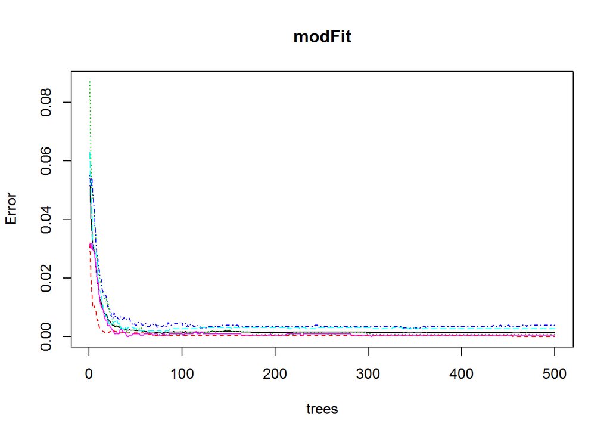

```r
## Plot the model
plot(modFit)
```

```r
## Predicting Results on the Test Data
prediction_test <- predict(modFit, testing_final)
prediction_test
```

```
##  1  2  3 41  5  6  7  8  9 10 11 12 13 14 15 16 17 18 19 20
##  B  A  B  A  A  E  D  B  A  A  B  C  B  A  E  E  A  B  B  B
## Levels: A B C D E
```